# Дисперсионный анализ для зависимых выборок (Reapeted ANOVA)

Литвинцев И.С

28 ноября 2017 г

## Дисперсионный анализ для зависимых выборок

### 1. Подготовка данных

Исследуются данные о недоношенных младенцах, у которых вовремя не закрылся артериальный проток. Выполним проверку значимости фактора пола (Sex) и фактора времени на зависимую переменную “масса” в два момента времени (Weight1 и Weight2).

Факторы:

1. Sex - Пол (1-м, 2-д)
2. Индивиды
3. Время (измерения веса в 1-ый и 2-ой моменты времени - Weight1, Weight2)

Зависимая переменная:

values - Масса

```r
data <- read.csv("C:/Users/806263/Desktop/SPbU/Магистратура Матмех (2017-2019)/Применение статистических методов к реальным данным/Данные/baseMA.csv", sep = ";", dec = ".")

data <- data[, c("Sex", "Weight1", "Weight2")]
data <- na.omit(data)
head(data)
```

```
##    Sex Weight1 Weight2
## 4    1    1220    1290
## 13   1    1430    1615
## 16   1     990    1239
## 18   2    1190    1140
## 21   2     720     753
## 22   1     850     850
```

Посчитаем количество элементов в каждой группе.

```r
n.i <- tapply(X = data$Weight1, INDEX = data$Sex, FUN = length); n.i
```

```
##  1  2
## 75 36
```

С помощью функции stack() cведем переменную вес в один признак (values).

```r
t <- ncol(data) - 1; #число уровней фактора С (число временных точек)

data.stack <- data.frame(stack(data[,-1]),
              individ = as.factor(rep(seq(nrow(data)), t)),
              Sex = as.factor(rep(data$Sex, t)))
names(data.stack)[2] <- "time"
head(data.stack)
```

```
##   values    time individ Sex
## 1   1220 Weight1       1   1
## 2   1430 Weight1       2   1
## 3    990 Weight1       3   1
## 4   1190 Weight1       4   2
## 5    720 Weight1       5   2
## 6    850 Weight1       6   1
```

```r
n <- n.i[1] + n.i[2] # число уровней фактора B (число индивидов)
r <- length(unique(data.stack$Sex)) # число уровней фактора А (число различных полов)

data.frame(n=n, t=t, r=r)
```

```
##     n t r
## 1 111 2 2
```

### 2. Модель дисперсионного анализа для зависимых выборок

Рассмотрим данные вида $x_{(i)jk}$, где $i \in 1:r$ – уровни фактора A (пол) с фиксированными эффектами, $j \in 1:n$ – уровни фактора B (индивиды), $k \in 1:t$ – уровни временного фактора C со случайными эффектами. Поскольку фактор A является следствием фактора индивида, то его индекс при наличии индекса $j$ заключаем в скобки, $n_1 + \ldots + n_r = n$. Требуется выяснить влияние факторов A и C на переменную Weight (вес, измеренный в два момента времени). Модель имеет вид:

$$x_{(i)jk} = \mu + \alpha_i + c_k + (\alpha c)_{ik} + \varepsilon_{(i)j}^1 + \varepsilon_{(i)jk}, \quad i \in 1:I, \: j \in 1:J, \: k=1:K$$

где $\varepsilon_{(i)j}^1$ – ошибка, обусловленная влиянием индивида, $\varepsilon_{(i)jk}$ - ошибка наблюдения, $\alpha_i$ – фиксированный дифференциальный эффект фактора Sex, $c_k$ – дифференциальный эффект фактора времени, величина $(\alpha c)_{ik}$ – эффект взаимодействия двух факторов; $\mu$ – генеральное среднее.

Найдем оценки параметров по формулам:
$$\hat{\mu} = \bar{x}_{***} = \frac{1}{nt}\sum_{k=1}^{t} \sum_{j=1}^{n} x_{(i)jk} = \frac{1}{nt}\sum_{i=1}^{r} \sum_{j=1}^{n_i} \sum_{k=1}^{t} x_{(i)jk}$$
$$\hat{\alpha_i} = \bar{x}_{i**} -\bar{x}_{***}$$
$$\bar{x}_{i**} = \frac{1}{n_i t}\sum_{k=1}^t \sum_{j=1}^{n_i} x_{(i)jk}, \qquad i \in 1:r$$
$$\bar{x}_{**k} = \frac{1}{n} \sum_{j=1}^{n} x_{(i)jk}, \qquad k \in 1:t$$
$$\bar{x}_{i*k} = \frac{1}{n_i} \sum_{j=1}^{n_i} x_{(i)jk}, \qquad i \in 1:r, \quad k \in 1:t$$
$$\bar{x}_{(i)j*} = \frac{1}{t} \sum_{k=1}^{t} x_{(i)jk}, \qquad i \in 1:r, \quad j \in 1:n$$
Рассчитаем $\bar{x}_{***}, \bar{x}_{i**}, \bar{x}_{**k}, \bar{x}_{i*k}, \bar{x}_{(i)j*}$:

```r
means <- list()
means$x <- mean(data.stack$values); means$x
```

```
## [1] 1034.261
```

```r
means$x.i <- tapply(X = data.stack$values, INDEX = data.stack$Sex, FUN = mean); means$x.i
```

```
##        1        2
## 1017.013 1070.194
```

```r
means$x.k <- tapply(X = data.stack$values, INDEX = data.stack$time, FUN = mean); means$x.k
```

```
##  Weight1  Weight2
## 1012.432 1056.090
```

```r
means$x.ik <- tapply(X = data.stack$values, INDEX = list(data.stack$Sex, data.stack$time), FUN = mean); means$x.ik
```

```
##    Weight1  Weight2
## 1  996.480 1037.547
## 2 1045.667 1094.722
```

```r
means$x.ij <- tapply(X = data.stack$values, INDEX = data.stack$individ, FUN = mean); means$x.ij
```

[output not shown]

Общий источник вариации $Q$ с числом степеней свободы $df_Q = nt-1$:
$$Q = \sum_{k=1}^t \sum_{j=1}^{n} \big(x_{(i)jk} - \bar{x}_{***}\big)^2$$

```r
SS <- list() # список, хранящий суммы квадратов
df <- list() # список, хранящий степени свободы сумм квадратов

SS$Q <- (data.stack$values - means$x)%*%(data.stack$values - means$x);
```

$$Q = Q_1 + Q_2,$$
где $Q_1$ – источник вариации, обусловленный различием индивидов, с числом степеней свободы $df_{Q_1} = n-1$:
$$Q_1 = t \sum_{j=1}^{n} \big(\bar{x}_{(i)j*} - \bar{x}_{***}\big)^2 = t\sum_{i=1}^{r} n_i \big( \bar{x}_{i**} - \bar{x}_{***}\big)^2 + t\sum_{j=1}^{n} \big( \bar{x}_{(i)j*} - \bar{x}_{i**}\big)^2 = Q_A +Q_{1e},$$
где $Q_A$ – источник вариации, обусловленный влиянием фатора А (пола), с числом степеней свободы $df_{Q_A} = r-1$:
$$Q_A = t\sum_{i=1}^{r} n_i \big( \bar{x}_{i**} - \bar{x}_{***}\big)^2,$$
а $Q_{1e}$ – ошибка с числом степеней свободы $df_{Q_{1e}}=n-r$:
$$Q_{1e} = t\sum_{j=1}^{n} \big( \bar{x}_{(i)j*} - \bar{x}_{i**}\big)^2.$$

```r
SS$Q.A <- t*(n.i[1]*(means$x.i[1] - means$x)^2 + n.i[2]*(means$x.i[2] - means$x)^2); SS$Q.A
```

```
##        1
## 137589.6
```

```r
ind <- data.stack$Sex == 1
man <- means$x.ij[ind]
tmp.man <- man[!is.na(man)]
woman <- means$x.ij[!ind]
tmp.woman <- woman[!is.na(woman)]


SS$Q.1e <- t*((tmp.man - means$x.i[1])%*%(tmp.man - means$x.i[1]) + (tmp.woman - means$x.i[2])%*%(tmp.woman - means$x.i[2])); SS$Q.1e
```

```
##          [,1]
## [1,] 49705947
```

```r
SS$Q.1 <- SS$Q.1e + SS$Q.A;

df$Q.A <- r-1
df$Q.1e <- n-r
```

Оставшийся исчтоник вариации $Q_2$ можно разложить на сумму источников вариаций, обусловленных влиянием временного фактора $C$, влиянием фактора взаимодествия факторов $A$ и $C$ (пола и времени) и ошибки $Q_{err}$.
$$Q_2 = Q - Q_1 = \sum_{k=1}^t \sum_{j=1}^{n} \big(x_{(i)jk} - \bar{x}_{(i)j*}\big)^2 = Q_C + Q_{AC} + Q_{err},$$
где $Q_C$ имеет число степеней свободы $df_{Q_C} = t-1$:
$$Q_C = n \sum_{k=1}^{t} \big( \bar{x}_{**k} - \bar{x}_{***}\big)^2.$$
$Q_{AC}$ имеет число степеней свободы $df_{Q_AC} = (t-1)(r-1)$:
$$Q_{AC} = \sum_{i=1}^r n_i \sum_{k=1}^{t} \big( \bar{x}_{i*k} - \bar{x}_{i**} - \bar{x}_{**k} + \bar{x}_{***} \big)^2.$$

И число степеней свободы $Q_{err}$ равно $df_{Q_{err}} = (t-1)(n-r)$:
$$Q_{err} = \sum_{j=1}^n \sum_{k=1}^{t} \big( \bar{x}_{(i)jk} - \bar{x}_{(i)j*} - \bar{x}_{i*k} + \bar{x}_{i**} \big)^2$$

```r
SS$Q.C <- n*(means$x.k - means$x)%*%(means$x.k - means$x); SS$Q.C
```

```
##          [,1]
## [1,] 105782.5
```

```r
tmp1 <- means$x.ik[1,] - means$x.i[1] - means$x.k + means$x
tmp2 <- means$x.ik[2,] - means$x.i[2] - means$x.k + means$x
SS$Q.AC <- n.i[1]*tmp1%*%tmp1 + n.i[2]*tmp2%*%tmp2; SS$Q.AC
```

```
##          [,1]
## [1,] 776.2177
```

```r
SS$Q.2 <- SS$Q - SS$Q.1
SS$Q.err <-  SS$Q.2 - SS$Q.C - SS$Q.AC; SS$Q.err
```

```
##         [,1]
## [1,] 2802513
```

```r
df$Q.C <- t-1
df$Q.AC <- (t-1)*(r-1)
df$Q.err <- (t-1)*(n-r)
```

#### 2.1. Гипотеза об отсутствии эффекта фактора пола (Sex)

$$H_0: \alpha_1 = ... = \alpha_r = 0$$
Для проверки этой гипотезы используется статистика
$$F = \frac{MQ_{A}}{MQ_{1e}} \sim F(df_{A}, df_{1e}),$$

```r
F <- list(); MSS <- list(); p.value <- list()
MSS$MQ.A <- SS$Q.A/df$Q.A;
MSS$MQ.1e <- SS$Q.1e/df$Q.1e
F$A <- MSS$MQ.A/MSS$MQ.1e; F$A
```

```
##           [,1]
## [1,] 0.3017197
```

```r
p.value$A <- 1-pf(F$A, df$Q.A, df$Q.1e); p.value$A
```

```
##           [,1]
## [1,] 0.5839299
```

При уровне значимости $\alpha = 0.05$ нет оснований отклонить гипотезу. Следовательно, нет значимого влияния фактора пола.

#### 2.2. Гипотеза об отсутствии случайного эффекта фактора времени

$$H_0: \sigma^2_C = 0$$

Для проверки этой гипотезы используется статистика
$$F = \frac{MQ_{C}}{MQ_{AC}} \sim F(df_{Q_C}, df_{Q_{AC}}),$$

```r
MSS$MQ.C <- SS$Q.C/df$Q.C;
MSS$MQ.AC <- SS$Q.AC/df$Q.AC;
F$C1 <- MSS$MQ.C/MSS$MQ.AC; F$C1
```

```
##          [,1]
## [1,] 136.2794
```

```r
p.value$C1 <- 1-pf(F$C, df$Q.C, df$Q.AC); p.value$C1
```

```
##           [,1]
## [1,] 0.0544009
```

При уровне значимости $\alpha = 0.05$ нет основания отклонить гипотезу. Случайный эффект фактора времени незначим.

#### 2.3. Гипотеза об отсутствии фиксированного эффекта фактора времени

$$H_0: с_1 = \ldots = c_t = 0$$

Для проверки этой гипотезы используется статистика
$$F = \frac{MQ_{C}}{MQ_{err}} \sim F(df_{Q_{C}}, df_{Q_{err}}),$$

```r
MSS$MQ.err <- SS$Q.err/df$Q.err;
F$C2 <- MSS$MQ.C/MSS$MQ.err; F$C2
```

```
##          [,1]
## [1,] 4.114269
```

```r
p.value$C2 <- 1-pf(F$C2, df$Q.C, df$Q.err); p.value$C2
```

```
##            [,1]
## [1,] 0.04496116
```

При уровне значимости $\alpha = 0.05$ отклоняем гипотезу. Фиксированный эффект фактора времени значим.

#### 2.4. Гипотеза об отсутствии эффекта взаимодействия двух факторов (Sex:time)

$$H_0: (\alpha c)_{11} = ... = (\alpha c)_{rt} = 0$$

Для проверки этой гипотезы используется статистика
$$F = \frac{MQ_{AC}}{MQ_{err}} \sim F(df_{AC}, df_{err}),$$

```r
F$AC <- MSS$MQ.AC/MSS$MQ.err; F$AC
```

```
##            [,1]
## [1,] 0.03018995
```

```r
p.value$AC <- 1-pf(F$AC, df$Q.AC, df$Q.err); p.value$AC
```

```
##           [,1]
## [1,] 0.8623822
```

p-значение больше уровня значимости $\alpha = 0.05$, следовательно влияние фактора взаимодействия незначимо.

### 3. Проверка результатов

Воспользуемся функцией aov() со специальной формулой для проверки резльтатов.

```r
formula <- values ~ Sex*time + Error(individ/time)
aov.out <- aov(formula, data=data.stack)
aov.S <- summary(aov.out); aov.S
```

```
##
## Error: individ
##            Df   Sum Sq Mean Sq F value Pr(>F)
## Sex         1   137590  137590   0.302  0.584
## Residuals 109 49705947  456018
##
## Error: individ:time
##            Df  Sum Sq Mean Sq F value Pr(>F)
## time        1  105783  105783   4.114  0.045 *
## Sex:time    1     776     776   0.030  0.862
## Residuals 109 2802513   25711
## ---
## Signif. codes:  0 '***' 0.001 '**' 0.01 '*' 0.05 '.' 0.1 ' ' 1
```

```r
pp <- c(pp1 <- aov.S[[1]][[1]][1,5], aov.S[[2]][[1]][seq(2),5])

names(pp) <- c("p.Sex", "p.time", "p.Sex:time"); pp
```

```
##      p.Sex     p.time p.Sex:time
## 0.58392988 0.04496116 0.86238222
```

```r
#wm <- with(data.stack, tapply(values, list(Sex, time), mean))
#Means <- list(wm=wm)
#list(pp=pp, Means=Means)
```

Сравнивая полученные значения, приходим к выводу, что все подсчеты верны.

```r
names(p.value) <- c("Sex", "time.rand", "time.fix", "Sex:time")
data.frame(p.value)
```

```
##         Sex time.rand   time.fix  Sex.time
## 1 0.5839299 0.0544009 0.04496116 0.8623822
```

**Вывод:** на исследуемый признак значимое влияние оказал лишь фиксированный эффект времени.

### 6. График эффекта взаимодействия

Построим Interaction plot переменных пол и время (Sex:time)

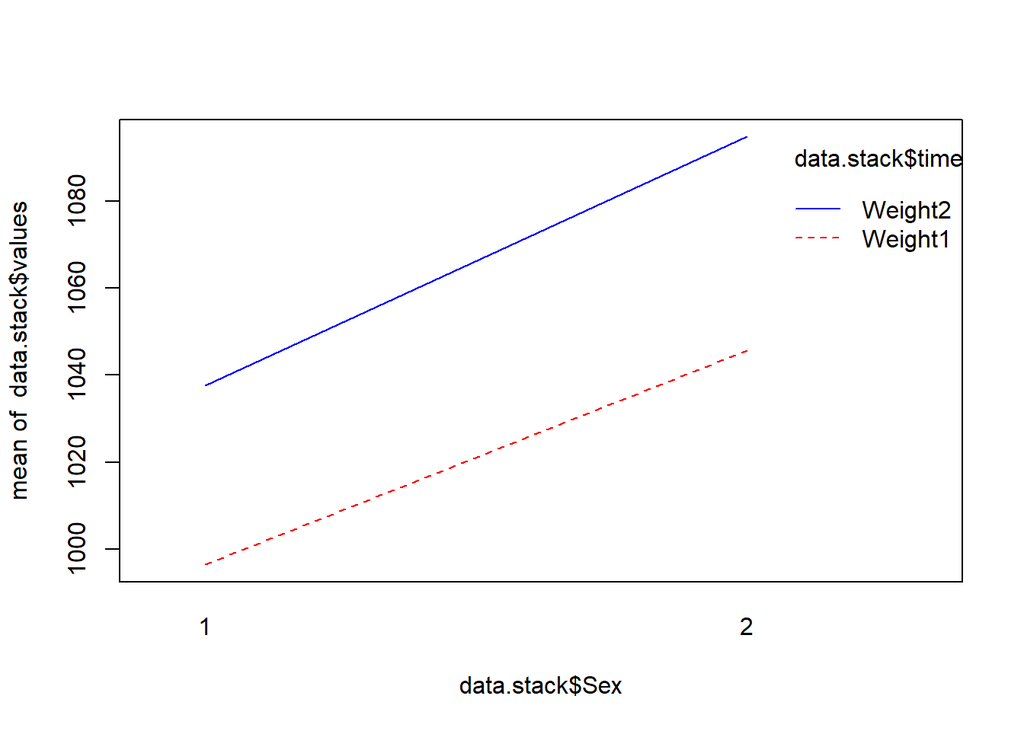

```r
interaction.plot(data.stack$Sex, data.stack$time,  data.stack$values, col = c("red", "blue"))
```

По графику видно, что эффекта взаимодействия нет.